# DAB300 - LAB 2 - CIFAR-10 Challenge

In this lab you will experiment with whatever ConvNet architecture/design you'd like on [CIFAR-10 image dataset](https://www.cs.toronto.edu/~kriz/cifar.html).

## GROUP NUMBER: 17

- Meghaben - W0749147
- Vipin - W0755900
- Yasmin - W0754285
- Urmi - W0756341
- Trang Bui - W0753523

## Part 1: Creating the network (50% of grade)

**Goal:** After training, your model should achieve **at least 80%** accuracy on a **validation** set within 20 epochs. (Or as close as possible as long as there is demonstrated effort to achieve this goal.)

**Data split** The training set should consist of 40000 images, the validation set should consist of 10000 images, and the test set should consist of the remaining 10000 images. **Please use the Keras `load_data()` function to import the data set.**

**Implementation** All code should be in Keras/python.

## The CIFAR-10 dataset

- The CIFAR-10 dataset consists of 60000 32x32 colour images in 10 classes, with 6000 images per class.
- There are 50000 training images and 10000 test images.
- The dataset is divided into five training batches and one test batch, each with 10000 images.
- The test batch contains exactly 1000 randomly-selected images from each class.
- The training batches contain the remaining images in random order, but some training batches may contain more images from one class than another
- Between them, the training batches contain exactly 5000 images from each class

```
*****Load dataset
*****PLOT 9 FIRST IMAGES
```

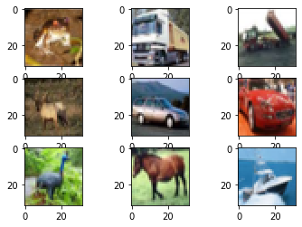

```
*****Use the first 10,000 samples of our training data as our validation set
partial_train_data: (40000, 32, 32, 3)
val_data: (10000, 32, 32, 3)
test_data: (10000, 32, 32, 3)
partial_train_labels: (40000, 1)
val_labels: (10000, 1)
test_labels: (10000, 1)
*****Encode labels
*****Model 2 Summary to see the tensor shapes and number of parameters for each layer
Model: "sequential"
_________________________________________________________________
Layer (type)                 Output Shape              Param #
=================================================================
conv2d (Conv2D)              (None, 32, 32, 32)        896
_________________________________________________________________
conv2d_1 (Conv2D)            (None, 32, 32, 32)        9248
_________________________________________________________________
max_pooling2d (MaxPooling2D) (None, 16, 16, 32)        0
_________________________________________________________________
dropout (Dropout)            (None, 16, 16, 32)        0
_________________________________________________________________
conv2d_2 (Conv2D)            (None, 14, 14, 64)        18496
_________________________________________________________________
conv2d_3 (Conv2D)            (None, 12, 12, 64)        36928
_________________________________________________________________
max_pooling2d_1 (MaxPooling2 (None, 6, 6, 64)          0
_________________________________________________________________
dropout_1 (Dropout)          (None, 6, 6, 64)          0
_________________________________________________________________
conv2d_4 (Conv2D)            (None, 4, 4, 128)         73856
_________________________________________________________________
conv2d_5 (Conv2D)            (None, 2, 2, 128)         147584
_________________________________________________________________
max_pooling2d_2 (MaxPooling2 (None, 1, 1, 128)         0
_________________________________________________________________
dropout_2 (Dropout)          (None, 1, 1, 128)         0
_________________________________________________________________
flatten (Flatten)            (None, 128)               0
_________________________________________________________________
dense (Dense)                (None, 128)               16512
_________________________________________________________________
dense_1 (Dense)              (None, 64)                8256
_________________________________________________________________
dense_2 (Dense)              (None, 10)                650
=================================================================
Total params: 312,426
Trainable params: 312,426
Non-trainable params: 0
_________________________________________________________________
Modelname: Sequential Model
Optimizer: adam
Loss categorical_crossentropy
Metrics accuracy
Model Compile with optimizer, loss function and evaluation method
Model Training to see the tensor shapes and number of parameters for each layer
Train on 40000 samples, validate on 10000 samples
Total Training Time (second): 1804.3797726631165
Visualize the progress our network makes on the loss and accuracy as the number of epochs increases.
```

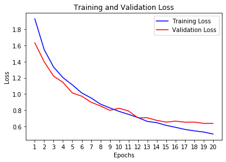

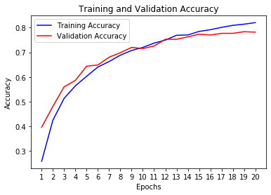

```
Prediction using test set.
0.7789
```

```python
import collections
import numpy as np
import matplotlib.pyplot as plt
import PIL
import time

import tensorflow as tf
from tensorflow import keras
from tensorflow.keras.datasets import cifar10
from tensorflow.keras.models import Sequential
from tensorflow.keras.layers import Conv2D, Flatten, Dense, Dropout
from tensorflow.keras.layers import MaxPooling2D
from tensorflow.keras.utils import to_categorical
from tensorflow.keras.callbacks import EarlyStopping

from tensorflow.keras.layers import BatchNormalization

# load train and test dataset
print('*****Load dataset')
(train_data, train_labels), (test_data, test_labels) = cifar10.load_data()

print('*****PLOT 9 FIRST IMAGES')
for i in range(9):
    plt.subplot(330 + 1 + i)
    plt.imshow(train_data[i]) # plot raw pixel data
plt.show()

print('*****Use the first 10,000 samples of our training data as our validation set')
val_data = train_data[:10000]
val_labels = train_labels[:10000]

# Use the remainder of the original training data for actual training
partial_train_data = train_data[10000:]
partial_train_labels = train_labels[10000:]

# Scale the pixel values so they lie in the range of 0-1
partial_train_data = partial_train_data / 255.
val_data = val_data / 255.
test_data = test_data /255.

print('partial_train_data:', partial_train_data.shape)
print('val_data:',val_data.shape)
print('test_data:',test_data.shape)
print('partial_train_labels:', partial_train_labels.shape)
print('val_labels:',val_labels.shape)
print('test_labels:',test_labels.shape)

# Reshape Image
width=32
height=32
depth=3
input_shape = (width, height, depth)
partial_train_data = partial_train_data.reshape(partial_train_data.shape[0], width, height, depth)
test_data = test_data.reshape(test_data.shape[0], width, height, depth)
val_data = val_data.reshape(val_data.shape[0], width, height, depth)

print('*****Encode labels')
partial_train_labels = to_categorical(partial_train_labels)
val_labels = to_categorical(val_labels)
test_labels = to_categorical(test_labels)

##################################################################################################################
def fn_Train(modelname, model, p_optimizer, p_loss, p_metrics, p_train_data, p_train_labels, p_epochs, p_batch_size, p_val_data, p_val_labels, p_verbose,p_test_data, p_test_labels):
    print('Modelname:',modelname)
    print('Optimizer:', p_optimizer)
    print('Loss',p_loss)
    print('Metrics',p_metrics)

    early_stop = EarlyStopping(monitor = 'val_accuracy', patience = 3)

    start_time = time.time()

    print('Model Compile with optimizer, loss function and evaluation method')
    model.compile(optimizer=p_optimizer,
                loss=p_loss,
                metrics=[p_metrics])

    print('Model Training to see the tensor shapes and number of parameters for each layer')
    # The values for the training loss and accuracy, as well as the validation loss and accuracy, are stored in the history variable
    history = model.fit(p_train_data,
                    p_train_labels,
                    epochs = p_epochs,
                    batch_size = p_batch_size,
                    validation_data=(p_val_data, p_val_labels),
                    verbose = p_verbose)
    print('Total Training Time (second):', time.time() - start_time)

    print('Visualize the progress our network makes on the loss and accuracy as the number of epochs increases.')

    history.history.keys()
    history_dict = history.history # the dictionary that has the information on loss and accuracy per epoch

    loss_values = history_dict['loss']   # training loss
    val_loss_values = history_dict['val_loss'] # validation loss

    epochs = range(1, len(loss_values)+1)  #creates list of integers to match the number of epochs of training

    # code to plot the results
    plt.plot(epochs, loss_values, 'b', label="Training Loss")
    plt.plot(epochs, val_loss_values, 'r', label="Validation Loss")
    plt.title("Training and Validation Loss")
    plt.xlabel("Epochs")
    plt.xticks(epochs)
    plt.ylabel("Loss")
    plt.legend()
    plt.show()

    # As above, but this time we want to visualize the training and validation accuracy
    acc_values = history_dict['accuracy']
    val_acc_values = history_dict['val_accuracy']

    plt.plot(epochs, acc_values, 'b', label="Training Accuracy")
    plt.plot(epochs, val_acc_values, 'r', label="Validation Accuracy")
    plt.title("Training and Validation Accuracy")
    plt.xlabel("Epochs")
    plt.xticks(epochs)
    plt.ylabel("Accuracy")
    plt.legend()
    plt.show()


    print('Prediction using test set.')
    test_loss, test_acc = model.evaluate(test_data,  test_labels, verbose=p_verbose)
    print(test_acc)
##################################################################################################################


model = Sequential([
    Conv2D(filters=32, kernel_size=(3, 3), strides=1, padding='same', activation='relu', input_shape=input_shape), ##half padding
    Conv2D(filters=32, kernel_size=(3, 3), strides=1, padding='same', activation='relu'),
    MaxPooling2D(pool_size = (2,2)),
    Dropout(0.2),
    Conv2D(filters=64, kernel_size=(3, 3), strides=1, padding='valid', activation='relu'), ## no paading
    Conv2D(filters=64, kernel_size=(3, 3), strides=1,padding='valid', activation='relu'),
    MaxPooling2D(pool_size = (2,2)),
    Dropout(0.2),
    Conv2D(filters=128, kernel_size=(3, 3), strides=1, padding='valid', activation='relu'),
    Conv2D(filters=128, kernel_size=(3, 3), strides=1, padding='valid', activation='relu'),
    MaxPooling2D(pool_size = (2,2)),
    Dropout(0.2),
    Flatten(),
    Dense(128, activation='relu'),
    Dense(64, activation='relu'),
    Dense(10, activation='softmax')
])

print('*****Model 2 Summary to see the tensor shapes and number of parameters for each layer')
model.summary()

p_loss = 'categorical_crossentropy'
p_metrics = 'accuracy'
p_epochs=20
p_batch_size=256
p_verbose=1
p_optimizer= 'adam'
fn_Train('Sequential Model',model,p_optimizer,p_loss,p_metrics,partial_train_data,partial_train_labels, p_epochs, p_batch_size, val_data, val_labels, p_verbose,test_data,test_labels)
```

## Part 2: Describe What you did (50% of grade)

### 1. At frist, we came up with the model which is derived from the lab of "convolutions" for MNIST dataset. Below is the the first model.

model_1 = Sequential([  
Conv2D(filters=32, kernel_size=(3, 3), strides=1, padding='same', activation='relu',input_shape=input_shape),  
Conv2D(filters=32, kernel_size=(3, 3), strides=2, padding='valid',activation='relu'),  
Conv2D(filters=64, kernel_size=(3, 3), strides=1, padding='same', activation='relu'),  
Conv2D(filters=64, kernel_size=(3, 3), strides=2, padding='valid',activation='relu'),  
Flatten(),  
Dense(128, activation='relu'),  
Dense(10, activation='softmax')  
])

- We decided to start with the model from our lesson to understand about the structure and approach of convolution neuron network.
- We investigate to understand about the paramenters including filter, kernel_size, stride, padding in the convolution layer.

  ```
    - filter = 32 / 64: the number of output filter
    - kernel_size = (3,3): the size (heigh and width) of the filter that run over the image
    - stride = 1: the filter scan/move forward 1 stride each step
    - padding-"same"/"valid": add pixel around the image to avoid missing image features
  ```

- Then, we went through some activation functions, which are used to change the weight, learning rate, etc of neuron network to reduce loss, include sigmoid, relu, tanh. We decide to work with "relu" because we understand that its below algorithm return values in the range [0,1], this help our model easy to reach linear.
- The first things we would like to try is optimizers. We tried to combine this model with 3 different optimizers including "rmsprop", "adam", and "sgd" to see the affect. Moreover, we use the loss function "categorical_crossentropy", evaluation function "accuracy".
- As request, the model is trained with in 20 epochs. The model is trained with the batch size = 256 for 40,000 images of train set, and validated using 10,000 images.
- The results are like that:

  ```
    - "rmsprop": Total training time is 762 seconds. Validation loss descrease from the first epoch down to the 5th, then it increased from 1.03 to 2.36 from the 5th to the epoch 20th. The accuracy started from 0.32 (32%), then reached the max accuracy at 0.678 (67,8%)
    - "adam" : Total training time is 761. Validation loss increase from 1.1067 to 2.23. The accuracy started from 0.42 to 0.65
    - "SGD" : Total training time is 698. Validation loss steadily went from 2.28 down to 1.35. The accuracy increased from 0.17, and got peak at 0.51.
  ```

- We concluded that

  ```
    - "rmsprop" and "adam" nearly worked same. Loss and accuracy in training and validating phases have the same shapes when visualizing.
    - Although the training phase is good, which strongly reduces the loss and increases rapidly the accuracy, both the loss and accuracy have the trend of increasing for validating phase. We assumed that if we try with more epochs, the model may be overfitting.
    - "SGD" is not the good optimizer for CIFAR 10 because the model learnt slowly
  ```

- We decided to create other models

### 2. We created a new model that is combined using optimizers"rmsprop" and "adam". We didn't use "SGD" because we concluded it's not suitable for CIFAR-10 dataset. Below is the the second model.

model = Sequential([  
Conv2D(filters=32, kernel_size=(3, 3), strides=1, padding='same', activation='relu', input_shape=input_shape), ##half padding  
Conv2D(filters=32, kernel_size=(3, 3), strides=1, padding='same', activation='relu'),  
MaxPooling2D(pool_size = (2,2)),  
Dropout(0.2),  
Conv2D(filters=64, kernel_size=(3, 3), strides=1, padding='valid', activation='relu'), ## no paading  
Conv2D(filters=64, kernel_size=(3, 3), strides=1,padding='valid', activation='relu'),  
MaxPooling2D(pool_size = (2,2)),  
Dropout(0.2),  
Conv2D(filters=128, kernel_size=(3, 3), strides=1, padding='valid', activation='relu'),  
Conv2D(filters=128, kernel_size=(3, 3), strides=1, padding='valid', activation='relu'),  
MaxPooling2D(pool_size = (2,2)),  
Dropout(0.2),  
Flatten(),  
Dense(128, activation='relu'),  
Dense(64, activation='relu'),  
Dense(10, activation='softmax')  
])

  ```
    - "rmsprop": Total training time is 1778 seconds. Validation loss descrease from 1.58 down to 0.77 while the accuracy started from 0.42 (32%), then reached the max accuracy at 0.73 (73%)
  ```

### 4. Conclusion

Regarding to above experiment, we conclude that

- "adam" and "rmsprop" optimizers work nearly the same for CIFAR-10 dataset
- Adding pooling layer can reduce the size of input volumn (We can see detail in the "output shape" of the model summary above), this help to reduce computing in the network.
- Adding Dropout layer can reduce the number of connection of two layers, and reduce overfitting
- Properly choosing the batch-size is important. As our observation, batch size may impact to the training performance
- If we have more time, we would like to try with different loss functions, activation function, kernel size (5x5, 7x7, 11x11...), batch size and learning rate. Moreover, we will try to understand clearer how to calculate the weight and size of input and output.

### References

1. https://machinelearningmastery.com/dropout-regularization-deep-learning-models-keras/
2. https://www.google.com/search?rlz=1C1CHBF_enUS886US886&sxsrf=ALeKk036G7wNGjPh8iJ5on32K99j5PPXYw%3A1605311509985&ei=FRyvX8zoO5Wq1QGInqeoCA&q=from+tensorflow.keras.models+import+Sequential&oq=from+tensorflow.keras.models+import+Sequential&gs_lcp=CgZwc3ktYWIQAzIFCAAQyQMyAggAMgYIABAWEB4yBggAEBYQHjIGCAAQFhAeMgYIABAWEB46BwgjEOoCECdQhugGWP3rBmCn8gZoAXABeACAAaACiAGgApIBAzItMZgBAKABAaABAqoBB2d3cy13aXqwAQrAAQE&sclient=psy-ab&ved=0ahUKEwiMx7my24DtAhUVVTUKHQjPCYUQ4dUDCA0&uact=5
3. https://www.google.com/search?rlz=1C1CHBF_enUS886US886&sxsrf=ALeKk01N2yh5jCxdMSUdII2ZJePyiy_Xrw%3A1605311624107&ei=iByvX7-IBvKk5NoPmayc-AQ&q=how+to+increase+the+validation+accuracy&oq=how+to+increasee+the+valida&gs_lcp=CgZwc3ktYWIQARgAMgcIABDJAxANMgYIABAWEB4yBggAEBYQHjIGCAAQFhAe…_SdoAXABeACAAbADiAGmKJIBCjEuMTcuNi4yLjGYAQCgAQGqAQdnd3Mtd2l6sAEKwAEB&sclient=psy-ab